# Trabajo practico final Introduccion a la Ciencia de datos

Recurrencia de Accidente cerberovascular isquémico: frecuencia y factores de riesgo

Marquez F. $^1$ | $^1$Centro de Rehabilitación de Adultos CR, FLENI, Escobar, Buenos Aires. | Mail [^1]

02/08/2020

Abstract

**Introducción:** Comprender el pronóstico a largo plazo y determinar la recurrencia de pacientes con accidente cerebrovascular (ACV) continúa siendo un desafío en la actualidad. **Objetivo:** Me propongo describir la frecuencia de recurrencia y determinar los factores de riesgo involucrados para desarrollar un modelo predictivo de clasificación binaria que permita individualizar la probabilidad de recurrencia post-ACV. **Resultados:** Se incluyeron 212 pacientes de lo cuales el 25% presentaron un nuevo ACV. Se exploraron las varibles sociodemográficas y clínicas recolectadas durante la interación del primer evento cerebrovascular. En el análisis multivariable, ninguna de las variables estudiadas fue intependiente para determinar el riesgo de recurrencias. **Conclusion:** En esta población la edad, el genero, antecedente de cancer, la gravadad del ACV, el grado de discapacidad, el tipo de tratamiento realizado ni el tratamiento trombolitico fueron variables predictoras de un nuevo evento.  
[Link](http://github.com/fermarquez2019/DS_UBA) al repositorio en GitHub.

## Desarrollo de la pregunta de interés

Las características de los pacientes con ACV durante la itnernación, influyen en el riesgo de recurrencia?

## Carga de librerías y del dataframe

```r
# Cargar librerías
library(tidyverse)
library(readxl)
library(knitr)
library(kableExtra)
library(ggplot2)
library(ggthemes)
library(corrplot)
library(dplyr)
library(stringr)
library(hrbrthemes)
library(viridis)
library(GGally)
library(ggstatsplot)
library(boot)
library(table1)
library(finalfit)

# Importar dataset
df <- read_excel("/Users/fernandomarquez/Documents/Fleni/Investigacion/Epilepsia y ACV/recurrencias_seguimiento_incompleto.xlsx")

# Eliminar colunmas no utilies
df <- select (df,-c(ID, ...1,fecha_ingreso, fecha_egreso, control_fecha))


# Head del dataframe
head(df)

# Nombres de las columnas
colnames(df)
```

## Resumen del dataset

```r
# Resumen del dataframe
summary(df)
```

```
##  internacion_dias     edad_x          edad_y        genero_x
##  Min.   : 0.000   Min.   :21.00   Min.   :21.59   Length:212
##  1st Qu.: 2.000   1st Qu.:63.00   1st Qu.:61.02   Class :character
##  Median : 3.000   Median :71.67   Median :71.38   Mode  :character
##  Mean   : 4.837   Mean   :68.82   Mean   :68.49
##  3rd Qu.: 6.000   3rd Qu.:79.00   3rd Qu.:79.05
##  Max.   :41.000   Max.   :93.00   Max.   :93.45
##  NA's   :59                       NA's   :71
##       dx              TOAST_x            TOAST_y              ESUS
##  Length:212         Length:212         Length:212         Length:212
##  Class :character   Class :character   Class :character   Class :character
##  Mode  :character   Mode  :character   Mode  :character   Mode  :character
##
##
##
##
##  observaciones         NIHSSi_x         NIHSSi_y          mRSi_x
##  Length:212         Min.   : 0.000   Min.   : 0.000   Min.   :0.0000
##  Class :character   1st Qu.: 0.000   1st Qu.: 0.000   1st Qu.:0.0000
##  Mode  :character   Median : 2.000   Median : 2.000   Median :0.0000
##                     Mean   : 3.453   Mean   : 3.483   Mean   :0.6226
##                     3rd Qu.: 5.000   3rd Qu.: 4.000   3rd Qu.:1.0000
##                     Max.   :28.000   Max.   :28.000   Max.   :4.0000
##                                      NA's   :63
##  sala_inicio          ventana            tipo_tto         trombecotmia
##  Length:212         Length:212         Length:212         Length:212
##  Class :character   Class :character   Class :character   Class :character
##  Mode  :character   Mode  :character   Mode  :character   Mode  :character
##
##
##
##
##      rTPA           ca_asociado         prev2_alta         cierre_FOP
##  Length:212         Length:212         Length:212         Length:212
##  Class :character   Class :character   Class :character   Class :character
##  Mode  :character   Mode  :character   Mode  :character   Mode  :character
##
##
##
##
```

[output cut: 25 more lines]

```
##  Length:212         Length:212         Min.   :2014-05-27 00:00:00
##  Class :character   Class :character   1st Qu.:2017-04-09 12:00:00
##  Mode  :character   Mode  :character   Median :2017-08-17 00:00:00
##                                        Mean   :2017-10-06 04:10:26
##                                        3rd Qu.:2018-05-17 06:00:00
##                                        Max.   :2020-05-26 00:00:00
##                                        NA's   :28
##    control          tiempo_seguimiento
##  Length:212         Min.   :  10.0
##  Class :character   1st Qu.: 519.5
##  Mode  :character   Median : 758.5
##                     Mean   : 754.3
##                     3rd Qu.: 967.8
##                     Max.   :1920.0
##                     NA's   :30
```

## Exploracion de valores faltantes

```r
# Definir una funcion que cuente los NaNs y aplicarla al dataframe
na_count <- sapply(df, function(y) sum(length(which(is.na(y)))))

#Creo un dataframe con los valores nulos
na_count <- data.frame(na_count)
na_count
```

```
##                    na_count
## internacion_dias         59
## edad_x                    0
## edad_y                   71
## genero_x                  0
## dx                        0
## TOAST_x                   0
## TOAST_y                  59
## ESUS                      0
## observaciones             8
## NIHSSi_x                  0
## NIHSSi_y                 63
## mRSi_x                    0
## sala_inicio               0
## ventana                   0
## tipo_tto                  0
## trombecotmia             61
## rTPA                      0
## ca_asociado               0
## prev2_alta                4
## cierre_FOP                0
## NIHSSe_x                  0
## NIHSSe_y                 63
## mRSe_x                    0
## mRSe_y                   64
## diasTotal                 0
## diasUCV                   0
## diasUTI                   0
## diasPiso                  0
## obito                     0
## reinternaciones           0
## reinternacion1            0
## reinternacion2            0
## retiniano                 1
## criterio                 28
## ingreso                  28
## control                  28
## tiempo_seguimiento       30
```

EL dataframe presenta multiples columnas repetidas y algunas de llas con valores nulos, que no son de interes para el trabajo. Seleccionaremos entonces las variables de interes para trabajar mas comodamente y con menos errores.

## Seleccion de columnas de interés

De acuerdo a los valores nulos y el interes de las variables para este trabajo seleccionamos y renombramos las columnas.

```r
# Ver nombres de las columnas
colnames(df)

# Seleccionar y cambiar nombre de columnas
df<-df %>% select(edad_x, genero_x, dx, TOAST_x, ESUS, NIHSSi_x,
                  mRSi_x, sala_inicio, ventana, tipo_tto, trombecotmia, rTPA, ca_asociado,
                  prev2_alta, cierre_FOP, NIHSSe_x, mRSe_x, diasTotal,
                  diasUCV, diasUTI, diasPiso, reinternaciones,
                  reinternacion1, reinternacion2, retiniano, criterio, tiempo_seguimiento)          %>%rename(edad=edad_x, genero=genero_x, TOAST=TOAST_x, NIHSSi=NIHSSi_x,
               mRSi=mRSi_x, NIHSSe=NIHSSe_x, mRSe=mRSe_x)
```

## Preprocesado y exploracion de variables categoricas

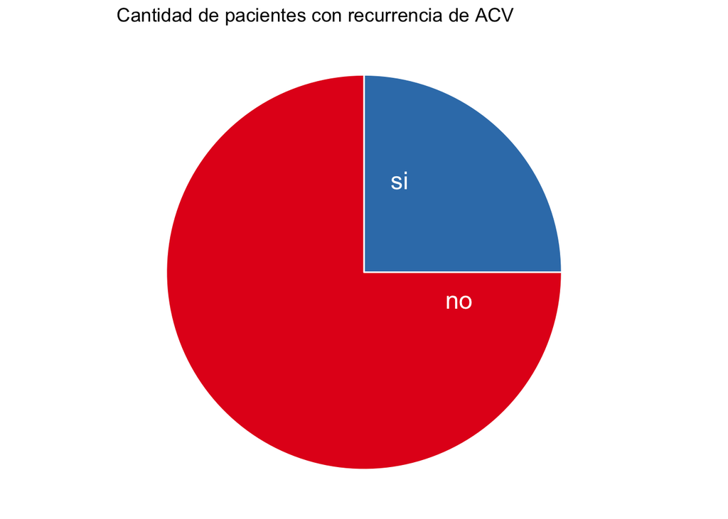

```r
# Obtener tipos de varibales
sapply(df, typeof)

# Identificar columnas categoricas y crear una lista
cat_cols <- unlist(lapply(df, is.character))

# Crear un subset solo de columnas categoricas
data_cat <- df[ , cat_cols]

# Creo vector de frecuencias de reinternaciones
tabla_reinternaciones <- table(data_cat$reinternaciones)

# Creo un df de frecuencias de reinternaciones
tabla_reinternaciones = as.data.frame(tabla_reinternaciones)

# Computar la posicion de las etiquetas
tabla_reinternaciones <- tabla_reinternaciones %>%
                          arrange(desc(Var1)) %>%
                          mutate(prop = Freq / sum(tabla_reinternaciones$Freq) *100) %>%
                          mutate(ypos = cumsum(prop)- 0.5*prop )

# Grafico de torta basico
ggplot(tabla_reinternaciones, aes(x="", y=Freq, fill=Var1)) +
  geom_bar(stat="identity", width=1, color="white") +
  coord_polar("y", start=0) +
  theme_void() + # remover background, grid, numeric labels
  theme(legend.position="none") +
  geom_text(aes(y = ypos, label = Var1), color = "white", size=6) +
  scale_fill_brewer(palette="Set1") +
  ggtitle("Cantidad de pacientes con recurrencia de ACV")
```

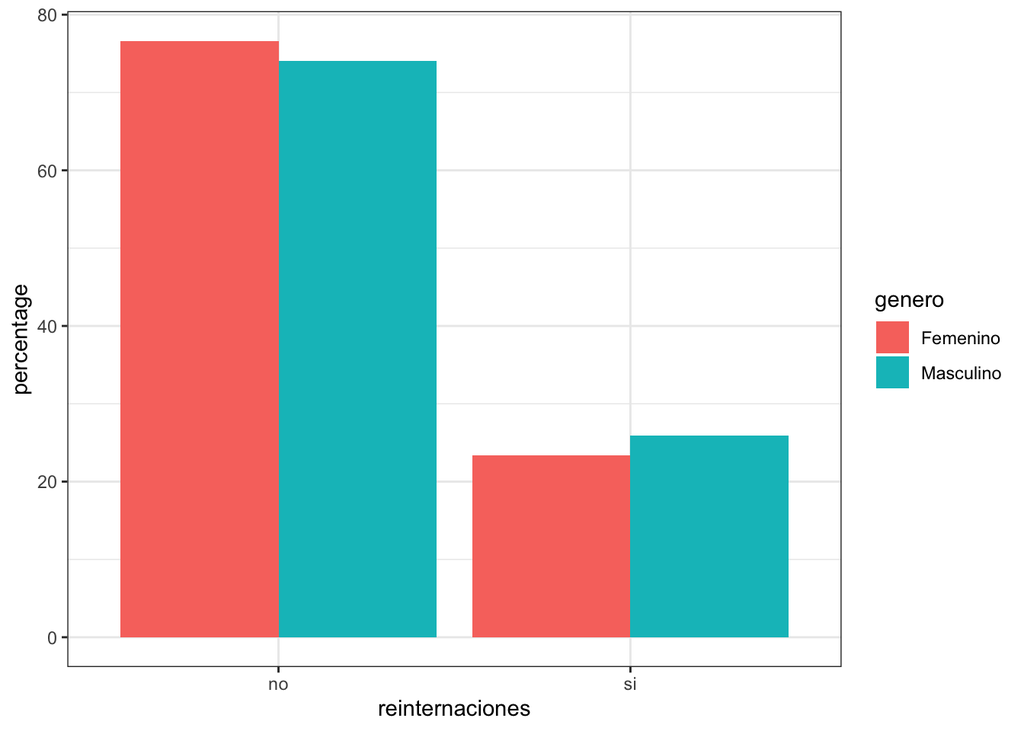

```r
# Creamos un nuevo dataframe con subgrupos por genero
df2 <- df %>%
  group_by(genero, reinternaciones) %>%
  tally() %>%
  complete(reinternaciones, fill = list(n = 0)) %>%
  mutate(percentage = n / sum(n) * 100)

# Ploteamos desagregando por grupos
ggplot(df2, aes(reinternaciones, percentage, fill = genero)) +
  geom_bar(stat = 'identity', position = 'dodge') +
  theme_bw()
```

La cantidad de recurrencias no es muy diferente al desagregar por genero.

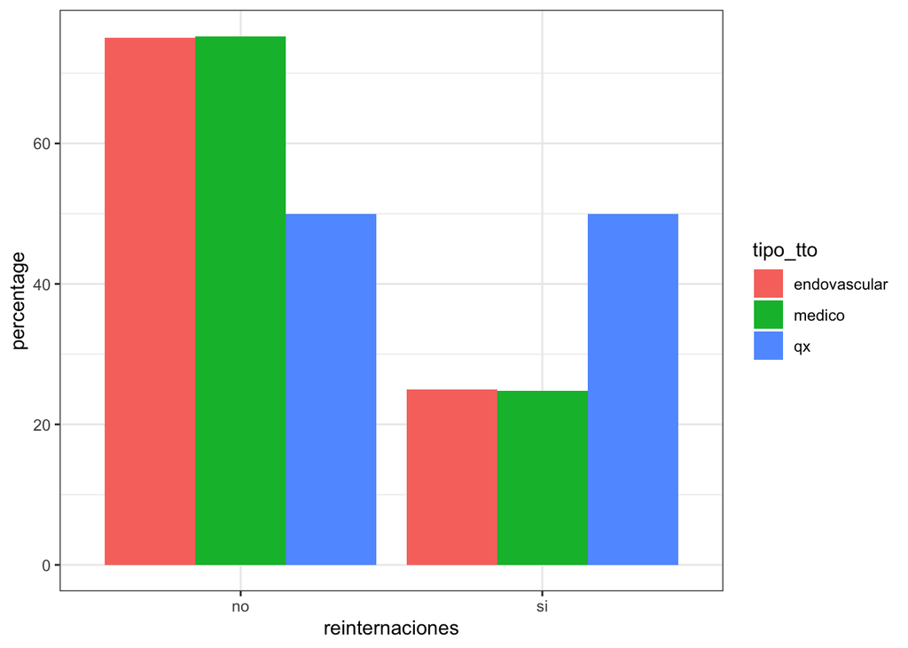

```r
# Creamos un nuevo dataframe con subgrupos de tipo de tratamiento
df2 <- df %>%
  group_by(tipo_tto, reinternaciones) %>%
  tally() %>%
  complete(reinternaciones, fill = list(n = 0)) %>%
  mutate(percentage = n / sum(n) * 100)

# Ploteamos desagregando por grupos
ggplot(df2, aes(reinternaciones, percentage, fill = tipo_tto)) +
  geom_bar(stat = 'identity', position = 'dodge') +
  theme_bw()
```

Podemos observar que los pacientes que si recurren parecen tener mas tratamientos quirurgicos.

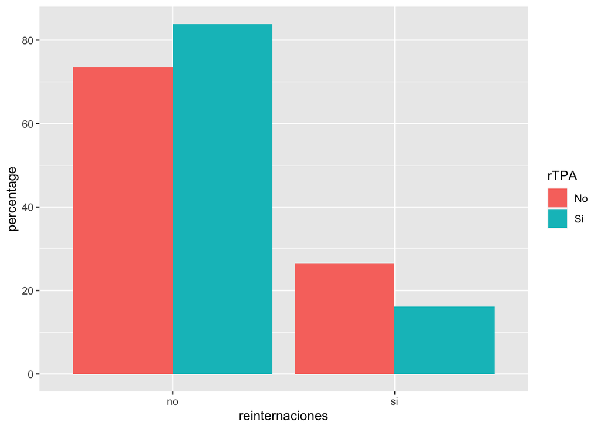

```r
# Creamos un nuevo dataframe con subgrupos rTPA (tratamiento trombolico)
df2 <- df %>%
  group_by(rTPA, reinternaciones) %>%
  tally() %>%
  complete(reinternaciones, fill = list(n = 0)) %>%
  mutate(percentage = n / sum(n) * 100)

# Ploteamos desagregando por grupos
ggplot(df2, aes(reinternaciones, percentage, fill = rTPA)) +
  geom_bar(stat = 'identity', position = 'dodge')
```

Veamos la gravedad del ACV segun la puntuación de la escala NIHSS al ingreso, desagregado por las causas según la clasifiación de TOAST[^2]

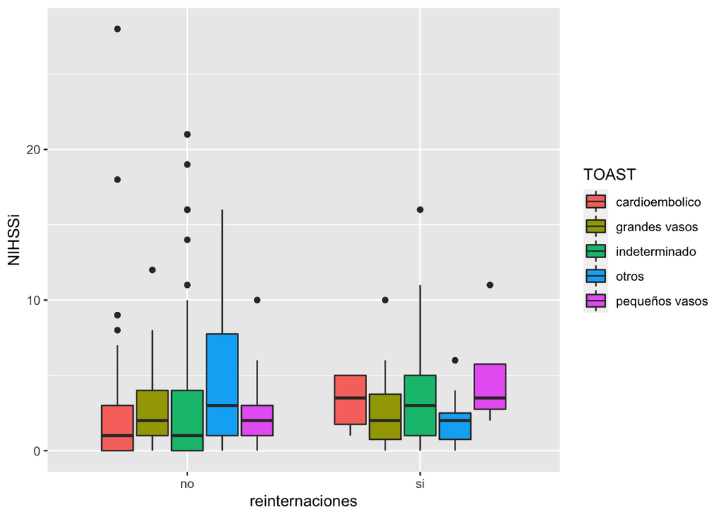

```r
# Boxplot agrupados por clasificacion etiológica del ACV, desagregado por recurrencia
ggplot(df, aes(x=reinternaciones, y=NIHSSi, fill=TOAST)) +
    geom_boxplot()
```

## Preprocesado de variables numéricas

Primero crearemos un dataset de variables numericas para no sobreescribir el dataset original, convirtiendo la variable dependiente (recurrencia) en una variable numérica para poder ampliar el análisis exploratorio.

```r
# Repasamos tipos de variables
sapply(df, typeof)

# Identificar columnas numericas y crear una lista
num_cols <- unlist(lapply(df, is.numeric))

# Crear un subset solo de columnas numericas
data_num <- df[ , num_cols]
```

## Exploracion de variables numericas y categoricas en una Tabla 1

```r
analisis<-df

# Agregar columna reinternaciones al nuevo dataset para tabla 1 para tabla
analisis<- cbind(recurrencia = c(analisis$reinternaciones), analisis)

# Creo un vector de la columna recurrencia codficada como si o no
recurrencia_v<-c(analisis$recurrencia)

# Mepeo/recodifico los valores que me da el vector (no lo convirtio en 1 y el si lo convirtio en 2)
analisis$recurrencia <- recode(recurrencia_v,'1'=0, '2'=1)

# Seteo etiquetas de tabla 1
label(analisis$genero)       <- "Genero"
label(analisis$edad)       <- "Edad"
label(analisis$TOAST)     <- "Clasificación TOAST"
label(analisis$NIHSSi) <- "NIHSS al ingreso"
label(analisis$mRSi) <- "Escala de Rankin Mdoifcada al ingreso"
label(analisis$sala_inicio) <- "Sala de internación al ingreso"
label(analisis$tipo_tto) <- "Tipo de tratmiento recibido"
label(analisis$rTPA) <- "Trombolisis"
label(analisis$ca_asociado) <- "Antecedente de cancer"
label(analisis$NIHSSe) <- "NIHSS al egreso"
label(analisis$diasTotal) <- "Total de días de internación"

# Seteo las unidades de la tabla 1
units(analisis$edad)       <- "años"
units(analisis$diasTotal)       <- "dias"

# Ploteo la tabla 1
tabla1<-table1(~ genero + edad + TOAST + NIHSSi + mRSi + sala_inicio + tipo_tto + rTPA + ca_asociado + NIHSSe + diasTotal | recurrencia, data=analisis,  overall="Total")

tabla1
```

|  | 0 (N=159) | 1 (N=53) | Total (N=212) |
| --- | --- | --- | --- |
| Genero |  |  |  |
| Femenino | 59 (37.1%) | 18 (34.0%) | 77 (36.3%) |
| Masculino | 100 (62.9%) | 35 (66.0%) | 135 (63.7%) |
| Edad (años) |  |  |  |
| Mean (SD) | 68.4 (14.5) | 70.0 (12.7) | 68.8 (14.1) |
| Median [Min, Max] | 71.7 [21.0, 93.0] | 71.7 [39.0, 91.0] | 71.7 [21.0, 93.0] |
| Clasificación TOAST |  |  |  |
| cardioembolico | 29 (18.2%) | 4 (7.5%) | 33 (15.6%) |
| grandes vasos | 17 (10.7%) | 8 (15.1%) | 25 (11.8%) |
| indeterminado | 73 (45.9%) | 29 (54.7%) | 102 (48.1%) |
| otros | 18 (11.3%) | 8 (15.1%) | 26 (12.3%) |
| pequeños vasos | 22 (13.8%) | 4 (7.5%) | 26 (12.3%) |
| NIHSS al ingreso |  |  |  |
| Mean (SD) | 3.45 (4.80) | 3.45 (3.49) | 3.45 (4.50) |
| Median [Min, Max] | 2.00 [0, 28.0] | 2.00 [0, 16.0] | 2.00 [0, 28.0] |
| Escala de Rankin Mdoifcada al ingreso |  |  |  |
| Mean (SD) | 0.591 (1.07) | 0.717 (1.15) | 0.623 (1.09) |
| Median [Min, Max] | 0 [0, 4.00] | 0 [0, 4.00] | 0 [0, 4.00] |
| Sala de internación al ingreso |  |  |  |
| Guardia | 1 (0.6%) | 0 (0%) | 1 (0.5%) |
| Sala | 2 (1.3%) | 1 (1.9%) | 3 (1.4%) |
| Sala telemetría | 2 (1.3%) | 1 (1.9%) | 3 (1.4%) |
| UCV | 146 (91.8%) | 49 (92.5%) | 195 (92.0%) |
| UTI | 8 (5.0%) | 2 (3.8%) | 10 (4.7%) |
| Tipo de tratmiento recibido |  |  |  |
| endovascular | 9 (5.7%) | 3 (5.7%) | 12 (5.7%) |
| medico | 149 (93.7%) | 49 (92.5%) | 198 (93.4%) |
| qx | 1 (0.6%) | 1 (1.9%) | 2 (0.9%) |
| Trombolisis |  |  |  |
| No | 133 (83.6%) | 48 (90.6%) | 181 (85.4%) |
| Si | 26 (16.4%) | 5 (9.4%) | 31 (14.6%) |
| Antecedente de cancer |  |  |  |
| no | 153 (96.2%) | 48 (90.6%) | 201 (94.8%) |
| si | 6 (3.8%) | 5 (9.4%) | 11 (5.2%) |
| NIHSS al egreso |  |  |  |
| Mean (SD) | 2.12 (3.66) | 2.91 (4.68) | 2.32 (3.94) |
| Median [Min, Max] | 1.00 [0, 23.0] | 1.00 [0, 25.0] | 1.00 [0, 25.0] |
| Total de días de internación (dias) |  |  |  |
| Mean (SD) | 4.88 (5.28) | 5.96 (8.44) | 5.15 (6.22) |
| Median [Min, Max] | 3.00 [0, 41.0] | 3.00 [1.00, 51.0] | 3.00 [0, 51.0] |

En la Tabla 1 se analizó las variables numericas mediante la media, pero observando el valor del desvío estándar, es evidente que deben tener distribuciones no normales, ya que restando el desvío estándar a la media, los valores mínimos serían negativos y dada la naturaleza de estas viarables, esto no es posible. Sería interesante explorar más en profundidad las distribuciones.

## Distribuciones de las variables numericas

Realizamos un analisis exploratorio con Histogramas para valorar graficamente las distribuciones

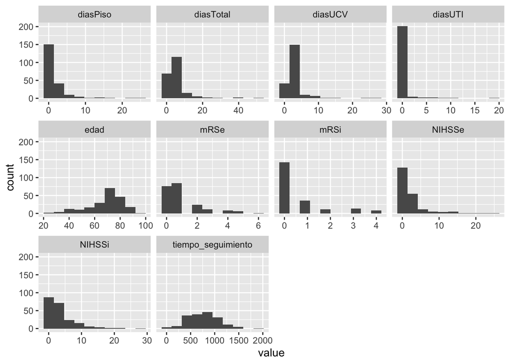

```r
# Crear mutiples historgamas de exploración
ggplot(gather(data_num), aes(value)) +
    geom_histogram(bins = 10) +
    facet_wrap(~key, scales = 'free_x')
```

Pareciera que algunas variables como por ejemeplo edad y tiempo de seguimiento pudiesen tener distribucion normal, pero buscaremos los estadísticos generando una funcion en la cual aplique el test de Shapiro Wilk al subset de variables numericas defenido anteriormente (data_num).

Otra observación es que pareciera que la escala NIHSS (que determina la gravedad del evento cerebro vascular) al egreso impresiona presentar una tendencia a ser menor que al ingreso, lo cual hablaria de una mejoría de los pacientes. Esto es habitual de ver el practica, una pregunta sería si tiene algun tipo de correlación con alguna variable.

```r
# Genero una funcion en la cual aplique el test de Shapiro al subset de varibales numericas
lshap <- lapply(data_num, shapiro.test)
# Genero un resumen de los resultados con los estdísticos de interés
lres <- sapply(lshap, `[`, c("statistic","p.value"))
lres
```

```
##           edad         NIHSSi       mRSi         NIHSSe       mRSe
## statistic 0.9289034    0.7361302    0.62478      0.6034059    0.7815883
## p.value   1.298704e-08 4.241571e-18 2.594811e-21 7.631671e-22 1.723676e-16
##           diasTotal    diasUCV      diasUTI      diasPiso
## statistic 0.55329      0.5279193    0.1911207    0.5257168
## p.value   5.215292e-23 1.463142e-23 2.617496e-29 1.313575e-23
##           tiempo_seguimiento
## statistic 0.9881839
## p.value   0.1333811
```

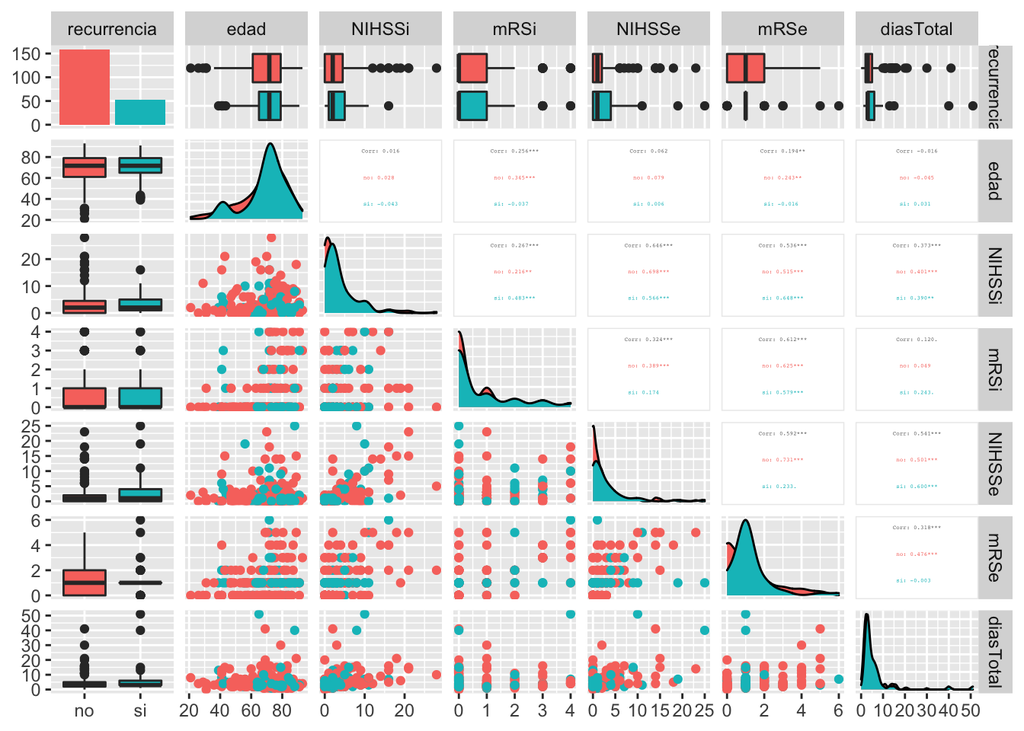

```r
# Agregar columna reinternaciones al subset de variables numericas
data_num<- cbind(recurrencia = c(df$reinternaciones), data_num)

# Eliminamos algunas columnas que no nos itneresa plotear
data_num <- select (data_num,-c(diasUTI, diasPiso, diasUCV, tiempo_seguimiento))

# Ploteamos las columnas de interés separando por grupos
ggpairs(data_num,
        aes(color = recurrencia),
        upper = list(continuous = wrap("cor", size = 1)),
        #upper = list(continuous = "density", combo = "dot_no_facet"),
        lower = list(continuous = "points", combo = "box_no_facet")
        ) #+ scale_fill_manual(values = my_colors)
```

No pareciera que las variables numericas estudiadas separen bien los datos de acuerdo al resultado de interés (recurrencia del evento cerebrovascular).

Intentaremos obtener más información con un grafico de correlaciones mediaten el Método de Spearman, considerando que las variables no tienen distribución normal.

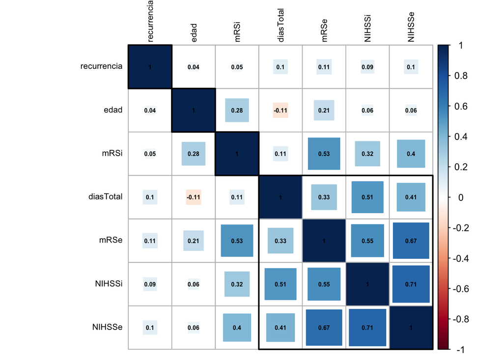

```r
# Creo un vector de la columna recurrencia codficada como si o no
recurrencia_v<-c(data_num$recurrencia)

# Mepeo/recodifico los valores que me da el vector (no lo convirtio en 1 y el si lo convirtio en 2)
data_num$recurrencia <- recode(recurrencia_v,'1'=0, '2'=1)

#Convertir al dataframe en una matriz numerica para poder plotear un heatmap
data_num_matrix<- as.matrix(data_num[,])


# Creo una matriz de correlaciónes entre variables con el metodo Spearman
cc = cor(data_num_matrix, method = "spearman")

# Ploteo el grafico de correlaciones ordenado de acuerdo al valor de Rho de Spearman y gregando los coeficientes de correlacion en el grafico
corr2<- corrplot(cc, tl.col = "black", order = "hclust", hclust.method = "average", addrect = 4, tl.cex = 0.7, method = "square", addCoef.col = TRUE, number.cex=0.5)
```

Existen algunas correlaciones moderadas entre las escalas de puntiación de severidad de ACV al ingreso y al egreso (NIHSSi-NIHSSe) y con la escala de Rankin Modificada (discapacidad) (mRSi-mRSe). Estas correlaciones son esperables y no son clinicamente relevantes. No impresiona que la recurrencia del evento presente correlaciones relevantes con las variables numéricas ploteadas.

Para tener mas certezas realizaremos un análisis unviariado.

```r
# Realizar un análisis univariado

explanatory = c('edad', 'genero', 'TOAST', 'NIHSSi', 'mRSi', 'sala_inicio', 'tipo_tto', 'rTPA', 'ca_asociado', 'NIHSSe', 'diasTotal')

dependent = "recurrencia"
analisis_univariado<-analisis %>%
                      summary_factorlist(dependent, explanatory,
                      p=TRUE, add_dependent_label=TRUE)

analisis_univariado
```

```
##                 Dependent: recurrencia                      unit     value
##                                   Edad     [21.0,93.0] Mean (sd) 0.2 (0.4)
##                                 Genero        Femenino Mean (sd) 0.2 (0.4)
##                                              Masculino Mean (sd) 0.3 (0.4)
##                    Clasificación TOAST  cardioembolico Mean (sd) 0.1 (0.3)
##                                          grandes vasos Mean (sd) 0.3 (0.5)
##                                          indeterminado Mean (sd) 0.3 (0.5)
##                                                  otros Mean (sd) 0.3 (0.5)
##                                         pequeños vasos Mean (sd) 0.2 (0.4)
##                       NIHSS al ingreso      [0.0,28.0] Mean (sd) 0.2 (0.4)
##  Escala de Rankin Mdoifcada al ingreso       [0.0,4.0] Mean (sd) 0.2 (0.4)
##         Sala de internación al ingreso            Sala Mean (sd) 0.3 (0.6)
##                                        Sala telemetría Mean (sd) 0.3 (0.6)
##                                                    UCV Mean (sd) 0.3 (0.4)
##                                                    UTI Mean (sd) 0.2 (0.4)
##            Tipo de tratmiento recibido    endovascular Mean (sd) 0.2 (0.5)
##                                                 medico Mean (sd) 0.2 (0.4)
##                                                     qx Mean (sd) 0.5 (0.7)
##                            Trombolisis              No Mean (sd) 0.3 (0.4)
##                                                     Si Mean (sd) 0.2 (0.4)
##                  Antecedente de cancer              no Mean (sd) 0.2 (0.4)
##                                                     si Mean (sd) 0.5 (0.5)
##                        NIHSS al egreso      [0.0,25.0] Mean (sd) 0.2 (0.4)
##           Total de días de internación      [0.0,51.0] Mean (sd) 0.2 (0.4)
##      p
##  0.482
##  0.682
##
##  0.205
##
##
##
##
##  1.000
##  0.469
##  0.954
##
##
##
##  0.717
##
##
##  0.219
##
##  0.109
##
##  0.209
##  0.274
```

Ningun valor de p fue estadisticametne significativo en el análisis univariado.

## Modelo de regresión

Para cumplir con el objetivo de realizar una regresión realizaré un modelo de clasificacion binaria mediante una regresión logística

```r
#Seleciono variables interes para el modelo
analisis<-analisis %>% select(genero, TOAST, tipo_tto, rTPA, ca_asociado, edad, NIHSSi,mRSi,NIHSSe, diasTotal,recurrencia)

# Crear el training set
input_ones <- analisis[which(analisis$recurrencia == 1), ]  # todos 1's
input_zeros <- analisis[which(analisis$recurrencia == 0), ]  # todos 0's

set.seed(42)  # para que sea reproducible

input_ones_training_rows <- sample(1:nrow(input_ones), 0.7*nrow(input_ones))  # 1's
input_zeros_training_rows <- sample(1:nrow(input_zeros), 0.7*nrow(input_ones))  # 0's

training_ones <- input_ones[input_ones_training_rows, ]
training_zeros <- input_zeros[input_zeros_training_rows, ]
trainingData <- rbind(training_ones, training_zeros)

# Crear el Test set
test_ones <- input_ones[-input_ones_training_rows, ]
test_zeros <- input_zeros[-input_zeros_training_rows, ]
testData <- rbind(test_ones, test_zeros)

library(smbinning)

# segregar variables continuas y categoricas
factor_vars <- c ("genero", 'TOAST', 'tipo_tto', 'rTPA', 'ca_asociado')
continuous_vars <- c("edad", "NIHSSi",'mRSi','NIHSSe', 'diasTotal')

iv_df <- data.frame(VARS=c(factor_vars, continuous_vars), IV=numeric(10))  # init for IV

# computar variables categoricas
for(factor_var in factor_vars){
  smb <- smbinning.factor(trainingData, y="recurrencia", x=factor_var)  # WOE table
  if(class(smb) != "character"){ # heck if some error occured
    iv_df[iv_df$VARS == factor_var, "IV"] <- smb$iv
  }
}

# computar variables continuas
for(continuous_var in continuous_vars){
  smb <- smbinning(trainingData, y="recurrencia", x=continuous_var)  # WOE table
  if(class(smb) != "character"){  # any error while calculating scores.
    iv_df[iv_df$VARS == continuous_var, "IV"] <- smb$iv
  }
}

iv_df <- iv_df[order(-iv_df$IV), ]  # ordenar

logitMod <- glm(recurrencia ~ edad + genero + TOAST + NIHSSi + tipo_tto + rTPA + + ca_asociado, data=trainingData, family=binomial(link="logit"))

predicted <- plogis(predict(logitMod, testData))  # predicted scores
# o
predicted <- predict(logitMod, testData, type="response")  # predicted scores

# Resultados
summary(logitMod)
```

```
##
## Call:
## glm(formula = recurrencia ~ edad + genero + TOAST + NIHSSi +
##     tipo_tto + rTPA + +ca_asociado, family = binomial(link = "logit"),
##     data = trainingData)
##
## Deviance Residuals:
##     Min       1Q   Median       3Q      Max
## -1.8288  -1.0755  -0.1829   0.9858   1.9006
##
## Coefficients:
##                       Estimate Std. Error z value Pr(>|z|)
## (Intercept)         -1.011e+00  2.575e+00  -0.393    0.695
## edad                 7.856e-03  2.765e-02   0.284    0.776
## generoMasculino      5.820e-01  5.259e-01   1.107    0.268
## TOASTgrandes vasos   1.011e+00  1.206e+00   0.838    0.402
## TOASTindeterminado   7.273e-01  9.996e-01   0.728    0.467
## TOASTotros           1.396e+00  1.325e+00   1.054    0.292
## TOASTpequeños vasos -1.332e+00  1.430e+00  -0.931    0.352
## NIHSSi              -5.066e-02  6.205e-02  -0.816    0.414
## tipo_ttomedico      -2.599e-01  1.071e+00  -0.243    0.808
## tipo_ttoqx           1.443e+01  1.455e+03   0.010    0.992
## rTPASi              -9.932e-01  7.625e-01  -1.303    0.193
## ca_asociadosi        7.503e-01  1.018e+00   0.737    0.461
##
## (Dispersion parameter for binomial family taken to be 1)
##
##     Null deviance: 102.586  on 73  degrees of freedom
## Residual deviance:  89.441  on 62  degrees of freedom
## AIC: 113.44
##
## Number of Fisher Scoring iterations: 14
```

[^1]: Correspondencia al autor: fmarquez.mum@gmail.com
[^2]: https://www.ahajournals.org/doi/abs/10.1161/01.str.24.1.35